# Course Project Description

Luyang Zhang

3/20/2023

```r
knitr::opts_chunk$set(
    echo = FALSE,
    message = FALSE,
    warning = FALSE
)
```

## 2.Introduction

In 2019, Nicholas A. Steinmetz et al performed a neuron encoding research experiment on mice visual cortex and collecting neuron encoding data to investigate neurons’ involvement in perceptual decisions. Most previous studies only studies some certain regions in the brain action selection, whereas Steinmetz et al conducted a comprehensive data collection across different regions in mice brains. Since other studies have observed that neurons in many brain regions fire stimuli for movements, rewards, and other tasks, it indicates that neurons across different regions in the brain could have some strong correlation. Thus, their research could uncover some new correlation among neurons. However, their experiment cannot distinguish neuron stimuli for actions and choice-related signals.

## 3.Data Description

This is a Go-NoGo experiment in which two screens are presented to the subjects. Mice are supposed to react by turning a wheel connected to their front paw when they receive visual stimuli from the screens. The signal of turning and neuron spikes are recorded. Researchers used probes inserted into mice’s left hemisphere to receive information from mice’s visual cortex and how long subjects fire spikes.

The experiment also excluded the trials in which the movement onset was less than 125 or more than 400 ms post-stimulus onset to avoid the event that wheel were coincidentally turned before mice could react to the visual stimuli. Similarly, trials with 50 to 400 ms post-stimulus onset when no recorded movement were excluded.

Mice receive a water reward if they successfully turn the wheel to indicate the screen showing a higher contrast or they do not turn when no contrasts presented. If the screens give equal contrast, mice earn a reward by arbitrarily turning the wheel to either the left or right direction.

### 3.1 Descriptive Analysis

We created a new variable called `firing_rate` which stores the mean firing rate for each trial aggregated by the number of neurons and time. This variable is calculated by collapsing the `spks` variable in the original dataset. `spks` is a matrix in each trial. The row dimension records the number of spikes in the visual cortex and the column dimension represents the corresponding time bins defined in `time` variable in the original dataset. The mean firing rate for the $i^{th}$ session and $j^{th}$ trial is calculated as follow:

$$\text{Firing Rate}_{ij} = \frac{\sum_k\sum_l
(\text{spikes})_{ijkl}}{\text{number of
neuron}_{ij}\times\text{time}}_{ij}$$

where k is the index for neuron and l is the index for time. $k = 1, 2, …, n_k$ , $l=1,2,…,n_l$ .

We prepared the data frame by binding all five sessions’ data together using `rbind()` function. Note that in the original dataset, many neuron never reacted to the visual stimuli, but we still included these neurons for the analysis since the study is for correlation among neurons not only for visual encoding.

**Table 1**

| contrast_left | contrast_right | firing_rate | feedback_type | session |
| --- | --- | --- | --- | --- |
| 1 | 0 | 6.194 | 1 | 1 |
| 0 | 0.5 | 4.087 | 1 | 1 |
| 1 | 0.5 | 5.871 | 1 | 1 |
| 0 | 0 | 4.087 | 1 | 1 |
| 0.5 | 1 | 5.534 | -1 | 1 |
| 0 | 0 | 3.553 | -1 | 1 |

**Table 1** gives a snapshot of the head portion of the data frame after data manipulation. The variable `firing_rate` is a numeric variable, and the other four variables `contrast_left`, `contrast_right`, `feedback_type`, and `session` are factor variables. This is the data frame that we later used for ANOVA model, where firing rate is the response variable. There are two fixed effects factors: `contrast_left` and `contrast_right`, and one random effect `session`.

| session | Number of Trials |
| --- | --- |
| 1 | 214 |
| 2 | 251 |
| 3 | 228 |
| 4 | 249 |
| 5 | 254 |

**Table 2** summarized the the number of trials for each session. Then our total number of trials is the five sessions’ combined.

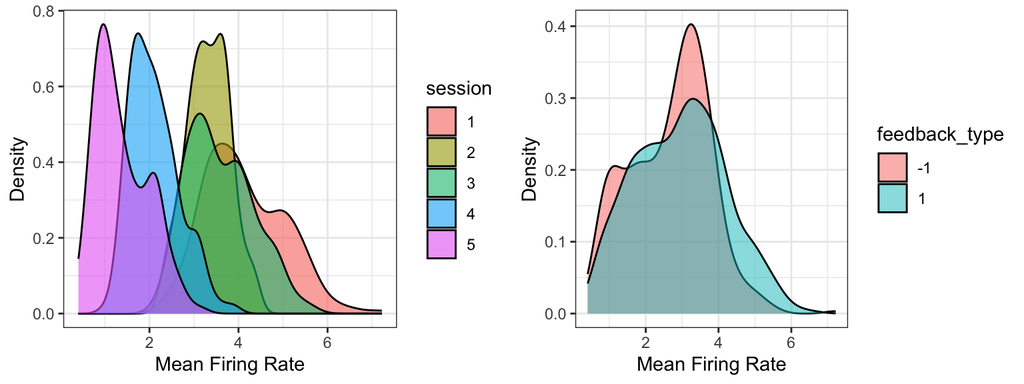

**Figure 1**

The firing rate distribution by different session is shown in the left density curves in **Figure 1**. The shape of distribution and mode for each session is different, so this suggests that `session` could bring a significant effect for influencing the mean firing rate.

The right density curve in **Figure 1** shows the distribution of mean firing rate by feedback type. This density curves suggest that sometimes the stimuli took longer to fire when the feedback type is reward. In the figure, it is noted that the curve for reward tails off slower than type penalty.

Penalty has more mean firing rate concentrated together as it has a notable higher peak value, though the mode for both types are roughly the same.

**Table 3(a)**

| contrast_left | contrast_right | firing_rate |
| --- | --- | --- |
| 1 | 0 | 6.194 |
| 1 | 0.5 | 5.871 |
| 0.5 | 0 | 5.562 |
| 0.5 | 0.5 | 5.534 |
| 0.5 | 1 | 5.534 |

**Table 3(b)**

| contrast_left | contrast_right | firing_rate |
| --- | --- | --- |
| 0 | 0 | 4.087 |
| 0 | 0.5 | 4.087 |
| 0 | 0.25 | 4.368 |
| 0.25 | 0.5 | 4.396 |
| 0.25 | 1 | 4.41 |

**Table 4(a)**

| contrast_right | n |
| --- | --- |
| 0 | 522 |
| 0.25 | 195 |
| 0.5 | 192 |
| 1 | 287 |

**Table 4(b)**

| contrast_left | n |
| --- | --- |
| 0 | 591 |
| 0.25 | 189 |
| 0.5 | 192 |
| 1 | 224 |

**Table 4(a)** and **Table 4(b)** shows number of observations for each levels of contrast right and left respectively. Both screens presented more zero contrast level than other three levels.

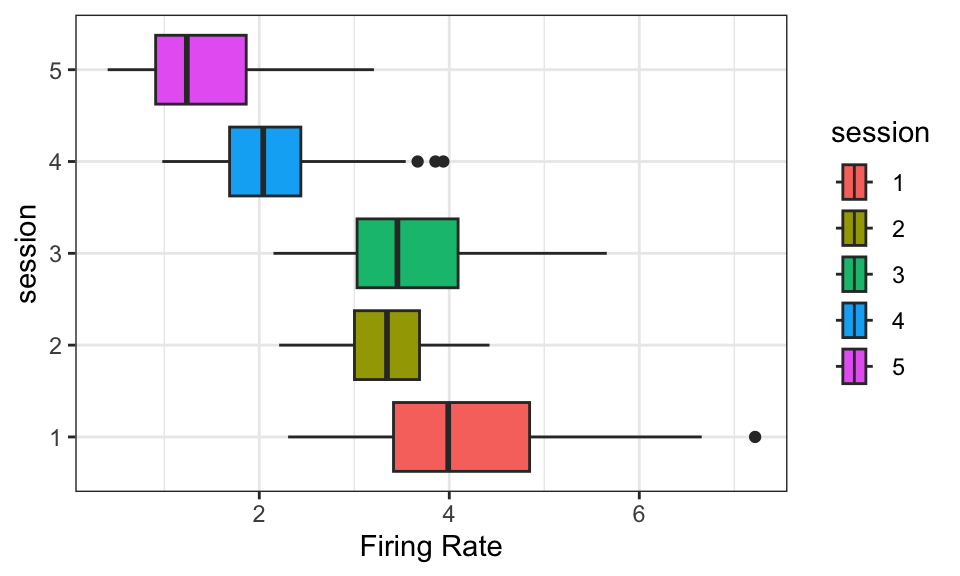

**Figure 2**

**Figure 2** is the boxplots of firing rate by each session. There are a three outliers in session 4 and one outlier in session 1. These outliers are all have higher than usual firing rates. And we can see that the mean and IQR for each session is quite different.

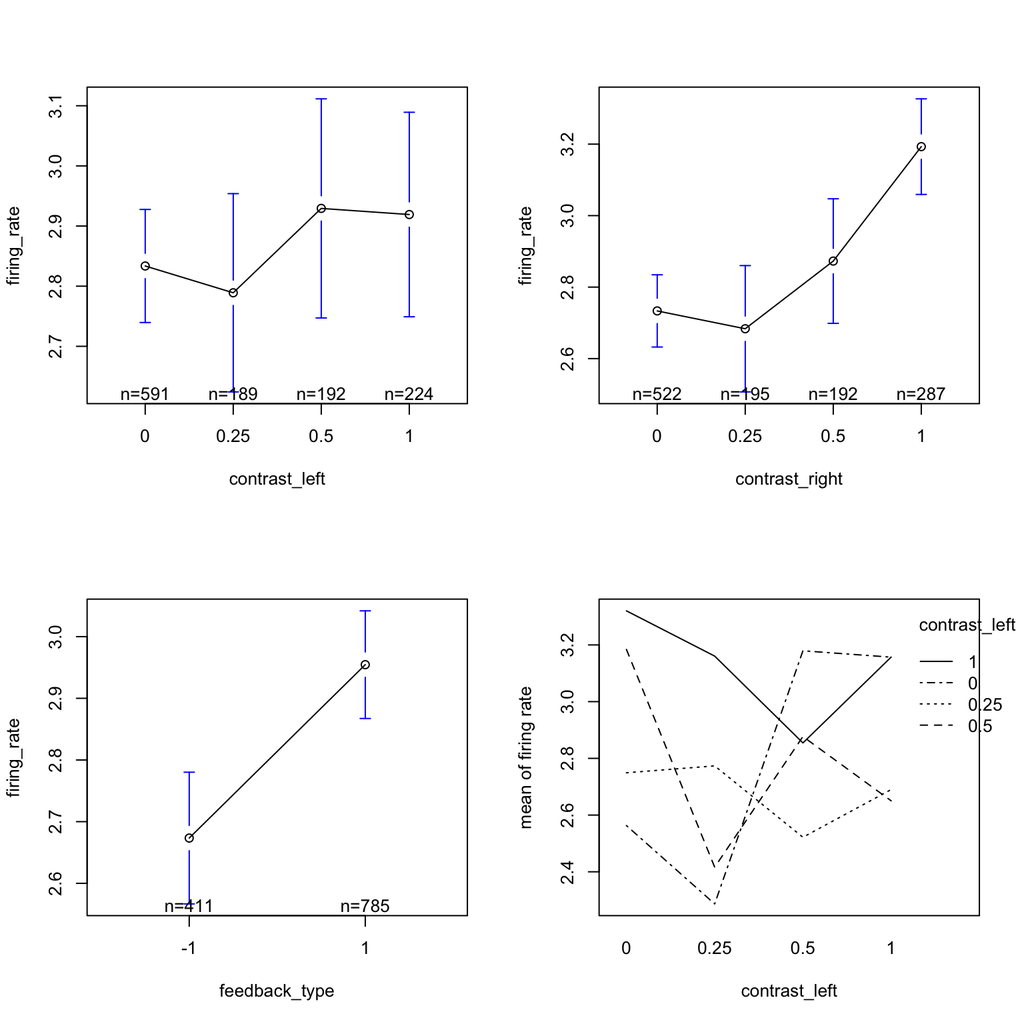

**Figure 3**

**Figure 3** shows the mean plots and interaction plots for the variables. The mean plots for left and right contrast shows when increasing contrast levels, the mean firing rate tend to increase. Both mean plots for contrasts show when contrast level is 0.5 or 1, the mean firing rate are higher than when level is 0 or 0.25.

The mean plots for feedback type shows a reward feedback has a longer mean firing rate. This aligns with our previous density curves for firing rate and feedback type.

The interaction plot shows the mean of firing rate when both contrast levels vary. Though it is hard to see a pattern, we conducted a more rigorous study in the next section of inferential analysis.

## 4. Inferential Analysis

### 4.1 Mixed Effect Model

To explain the variation in the mean firing rate, we used ANOVA models. We fit the mean firing rate to left contrast, right contrast and session. The full model is:
$$Y_{ijkl} =
\mu+\alpha_i+\beta_j+\gamma_{k}+(\alpha\beta)_{ij}+\epsilon_{ijkl}$$

where $\alpha_i$ and $\beta_j$ are the fixed-effect factors of $i^{th}$ left contrast and $j^{th}$ right contrast, respectively. $\gamma_{k}$ is the random effect of sessions, $(\alpha\beta)_{ij}$ is an interaction term of contrast left and contrast right. $\epsilon_{ijk}$ is the error terms. Specifically, we set up the a random intercept as session.

This model satisfies the following assumptions: (1) $\sum\alpha_i=0$, (2)$\sum\beta_j=0$, (3) $\gamma_k$ are i.i.d $N(0, \sigma^2_\gamma)$, (4) $\sum(\alpha\beta)_{ij}=0$, (5) $\epsilon_{ijkl}\stackrel{i.i.d}{\sim}N(0,\ \sigma^2)$

**Table 5(a)**

[output not shown]

**Table 5(b)**

| Groups | Name | Variance | Standard Deviation |
| --- | --- | --- | --- |
| Session | (Intercept) | 1.2667 | 1.1255 |
| Residual |  | 0.3995 | 0.6321 |
| Number of obs: 1196 | Groups: session , 5 |  |  |

**Table 5(a)** shows the fitted coefficients estimate by each pair of contrast levels, and **Table 5(b)** shows the variance and standard deviation for the random effect `session`. Then we are interested in testing if interaction term is significant in the model.

### 4.2 Model Selection

#### 4.2.1 Testing interaction term

$$H_0: (\alpha\beta)_{ij}=0\ vs.\ H_1:\
(\alpha\beta)_{ij} \ne0 \text{ for at least one pair of i,
j}$$
Namely, we compared these two models:

full model:
$$Y_{ijk} =
\mu+\alpha_i+\beta_j+\gamma_{k}+(\alpha\beta)_{ij}+\epsilon_{ijk}$$

additive-only model:
$$Y_{ijk} =
\mu+\alpha_i+\beta_j+\eta_{k(ij)}+\epsilon_{ijk}$$

**Table 6**

|  | npar | AIC | BIC | logLik | deviance | Chisq | Df | Pr(>Chisq) |
| --- | --- | --- | --- | --- | --- | --- | --- | --- |
| **model_add** | 9 | 2349 | 2395 | -1166 | 2331 | NA | NA | NA |
| **model_full** | 18 | 2350 | 2441 | -1157 | 2314 | 17.52 | 9 | 0.04112 |

Noted the reduced model is a nested model to the full model, we use `anova()` function to perform a likelihood ratio test. **Table 6** gives the summary output. The test statistic is the ratio of the maximum likelihood of the parameter of interest under null hypothesis and under the entire parameter space. It follows a Chi-square distribution which degrees of freedom is the number of difference in parameter between the two models.

In our case, since the p-value for our likelihood ratio test is 0.041 < 0.05, so we reject the null hypothesis that interaction does not exist. Thus, we prefer accepting the full model.

#### 4.2.2 Testing random effect

Next, we tested whether the random effect is significant.

$$H_0: \sigma^2=0\ vs.\ H_1:\ \sigma^2
\ne0$$

We now compare these two models:

full model:
$$Y_{ijk} =
\mu+\alpha_i+\beta_j+\eta_{k(ij)}+(\alpha\beta)_{ij}+\epsilon_{ijk}$$

fixed effects with interaction term model:
$$Y_{ijk} =
\mu+\alpha_i+\beta_j+(\alpha\beta)_{ij}+\epsilon_{ijk}$$

**Table 7** (continued below)

|  | npar | AIC | BIC | logLik | deviance | Chisq | Df |
| --- | --- | --- | --- | --- | --- | --- | --- |
| **model_fixed_full** | 17 | 3788 | 3874 | -1877 | 3754 | NA | NA |
| **model_full** | 18 | 2350 | 2441 | -1157 | 2314 | 1440 | 1 |

|  | Pr(>Chisq) |
| --- | --- |
| **model_fixed_full** | NA |
| **model_full** | 4.619e-315 |

**Table 7** shows the output of the summary for the model comparison. Here, we use the same likelihood ratio test for testing random effect. The p-value shows significant, so we reject the null hypothesis. Then we believe the random effect of `session` exists in the model. Therefore, our final model is still the full model, which states:

$$Y_{ijk} =
\mu+\alpha_i+\beta_j+\eta_{k(ij)}+(\alpha\beta)_{ij}+\epsilon_{ijk}$$

### 4.3 Sensitivity Analysis and Model Diagnostics

#### 4.3.1 Residual Studies

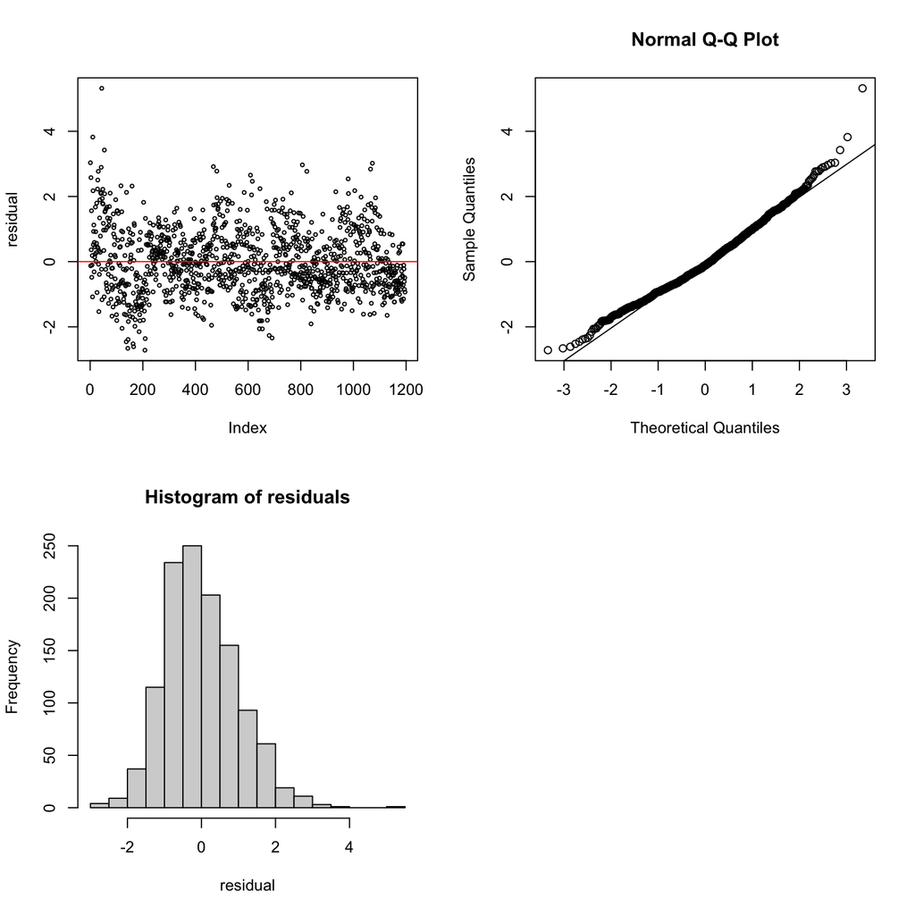

**Figure 4**

#### 4.3.2 Normality Test

**Table 8**

| Test statistic | P value |
| --- | --- |
| 0.9852 | 1.105e-09 * * * |

**Table 8** gives the Shapiro-Wilk normality test for residual. It also shows significant p-value, so the residuals are not normally distributed and then violate the model assumption.

#### 4.3.3 Homoskedasticity Test

**Table 9(a)**

|  | Df | F value | Pr(>F) |
| --- | --- | --- | --- |
| **group** | 15 | 1.117 | 0.3356 |
|  | 1180 | NA | NA |

**Table 9(b)**

|  | Df | F value | Pr(>F) |
| --- | --- | --- | --- |
| **group** | 15 | 3.696 | 2.192e-06 |
|  | 1180 | NA | NA |

We used Levene’s Test by `leveneTest()` function in `car` package. We first test the response variable `firing_rate` with respect to the contrast levels with interactions. **Table 9(a)** shows the test result, and p-value are not significant. So the data distribution itself satisfy the model assumption of homogeneity. Then we test the residual from the ANOVA model against contrast levels with interaction, as if the residuals are the response variable. **Table 9(b)** shows that the p-value became significant. So the residuals are not homogeneity.

#### 4.3.4 Outliers

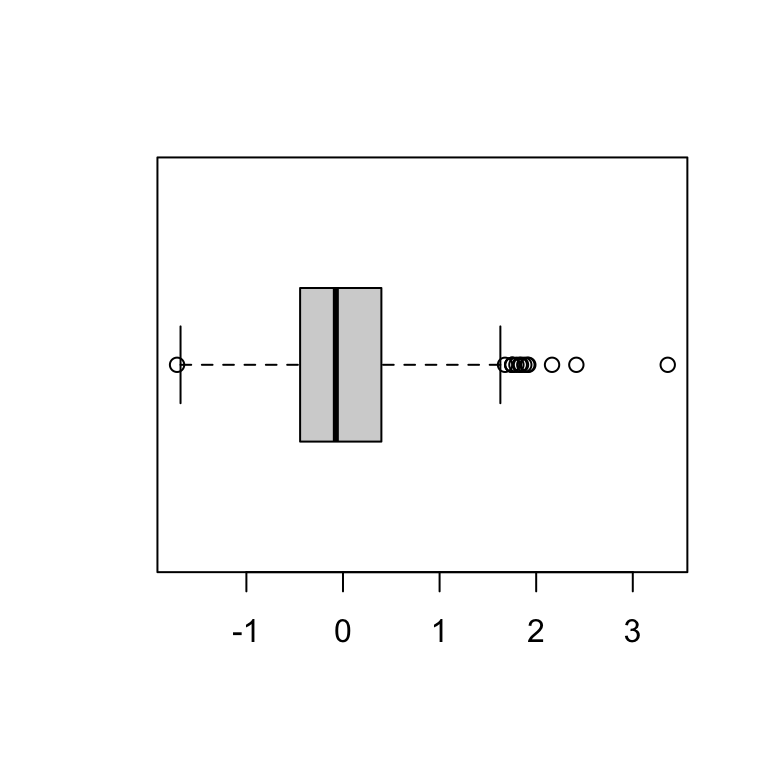

**Figure 5**

**Figure 5** is the box plot of residuals of the full model. There are several outliers that are unusually high, and there is a extremely small residual.

In conclusion, the ANOVA model gives some insight about how mean firing rate respond when we have different levels of contrast levels. It confirms that session should be considered as a random effect, so there is some variation due to sampling at each session of experiment.

In future studies, to reconcile the non-stationary issue with the data within each session, time series analysis could be done to incorporate autocorrelation between trials into the model.

## 5. Logistic Regression

In this section, we predicted the outcome of the feedback by training a classifier. Firstly, we split the data where the first 100 trials are in the test set and the rest of them are in the training set. We have 1096 observations combined from five sessions for training a classifier.

We choose the response variable as `feedback_type` and `contrast_right`, `contrast_left`, `firing_rate` and `session` as predictors.

The model is as follows:

$${\rm logit}(\pi_i) = \beta_0 + \beta_1x_1+\beta_2x_2+\beta_3x_3 +
\beta_4x_4$$

where $x_1$ is `contrast_left`, $x_2$ is `contrast_right`, $x_3$ is `firing_rate`, and $x_4$ is `session`. $\pi_i$ is the odds of mice getting a reward.

**Table 10**

|  | Estimate | Std. Error | z value | Pr(>\|z\|) |
| --- | --- | --- | --- | --- |
| **(Intercept)** | -2.455 | 0.4835 | -5.078 | 3.817e-07 |
| **contrast_left0.25** | -0.2042 | 0.198 | -1.031 | 0.3023 |
| **contrast_left0.5** | -0.4582 | 0.1944 | -2.357 | 0.0184 |
| **contrast_left1** | -0.2716 | 0.1896 | -1.433 | 0.152 |
| **contrast_right0.25** | -1.006 | 0.1982 | -5.077 | 3.843e-07 |
| **contrast_right0.5** | -0.9256 | 0.1974 | -4.689 | 2.743e-06 |
| **contrast_right1** | -0.9277 | 0.184 | -5.043 | 4.593e-07 |
| **firing_rate** | 0.9695 | 0.1245 | 7.784 | 7.009e-15 |
| **session2** | 0.4861 | 0.2538 | 1.915 | 0.05545 |
| **session3** | 0.3306 | 0.2562 | 1.291 | 0.1968 |
| **session4** | 1.88 | 0.3194 | 5.885 | 3.984e-09 |
| **session5** | 2.592 | 0.3851 | 6.731 | 1.68e-11 |

Using `summary()` function, we can access the estimators for each predictor. **Table 10** provides the summary output. Noted that all estimators for contrast levels are negative, so the baseline which both contrasts equal to zero gives the highest logit function. Thus the mice is easier to receive rewards compared to any other combination of contrast levels. Also, We found p-values for session 3 is not significant, so we fit another logistic regression model which `seesion` is excluded. We then conducted another likelihood ratio test using `anova()` function.

### 5.1 Model Selection

$$H_0: \beta_4=0\ vs.\ H_1:\ \beta_4
\ne0$$

**Table 11**

| Resid. Df | Resid. Dev | Df | Deviance | Pr(>Chi) |
| --- | --- | --- | --- | --- |
| 1088 | 1374 | NA | NA | NA |
| 1084 | 1313 | 4 | 60.92 | 1.858e-12 |

**Table 11** give the likelihood ratio test summary output. We tested if the coefficient for `session` is zero, so we set $\beta_4$ to 0 in the null hypothesis. The p-value shows significant, so we reject our null hypothesis and conclude that we accept the full model.

### 5.2 Model Testing

Then we test the model using the 100 observation of session 1 as the test dataset. `predict()` gave the predicted probability of receiving reward for each observation. Then we set our threshold as 0.5 and tabulated the confusion matrix (**Table 12**. The logistic regression model predict most reward type correct–only two observations are classified as penalty. However, more observation recorded as penalty are classified as reward. Thus, it has a True Positive Rate (TPR) of 97.3% and a False Positive Rate (FPR) of 76.92%. The overall accuracy is 78%.

**Table 12**

|  | Prediction |  |
| --- | --- | --- |
|  | -1 | 1 |
| Observation |  |  |
| -1 | 6 | 20 |
| 1 | 2 | 72 |

### 5.3 Logistic Model Diagnostics

#### 5.3.1 Pearson residuals and deviance residuals

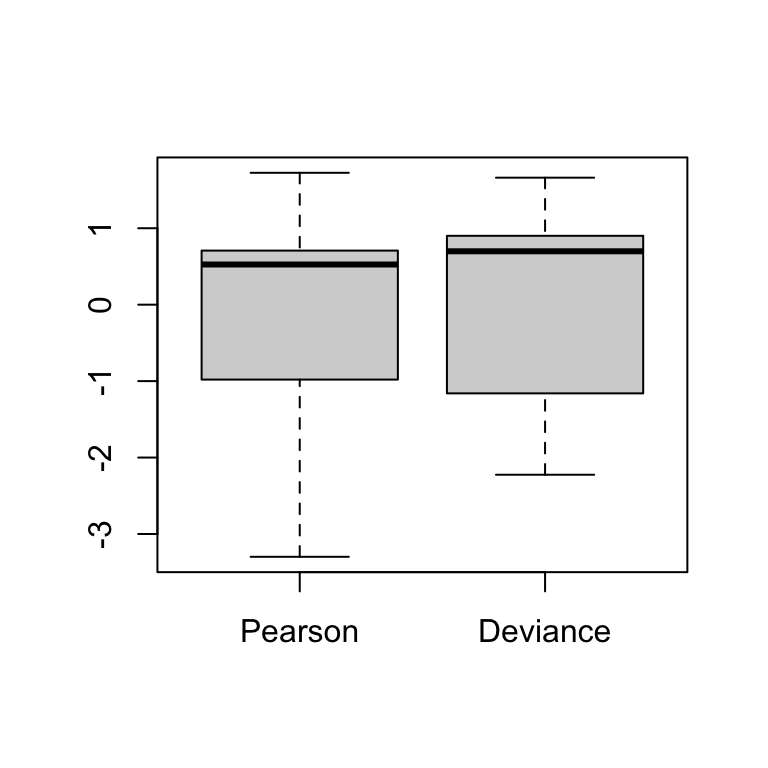

**Figure 6**

#### 5.3.2 Residual plots

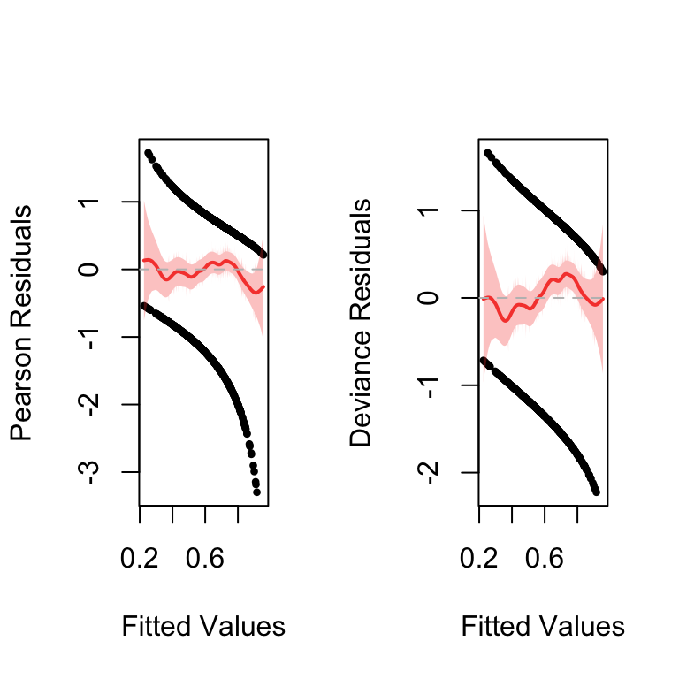

**Figure 8**

Secondly, we check the residual vs. fitted values plots. The key here is to check patterns for residuals. The red curves are smoother for the fitted values. They are roughly around zero except at extreme values.

#### 5.3.3 Leverage Points and Cook’s Distance

The fitted values of a linear model can be defined as $\hat{Y}=HY$. The diagonal of the hat matrix $H$ are called leverages. These leverage points give some implication on model’s goodness-of-fit. We looked for high leverage points which indicates the prediction can be unusual.

We used `hatvalues()` function in `stats` package to extract the diagonals of the hat matrix in the logistic regression model. In figure, there are two points that shows high leverage.

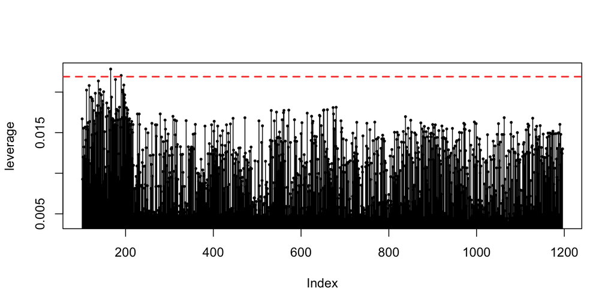

**Figure 9**

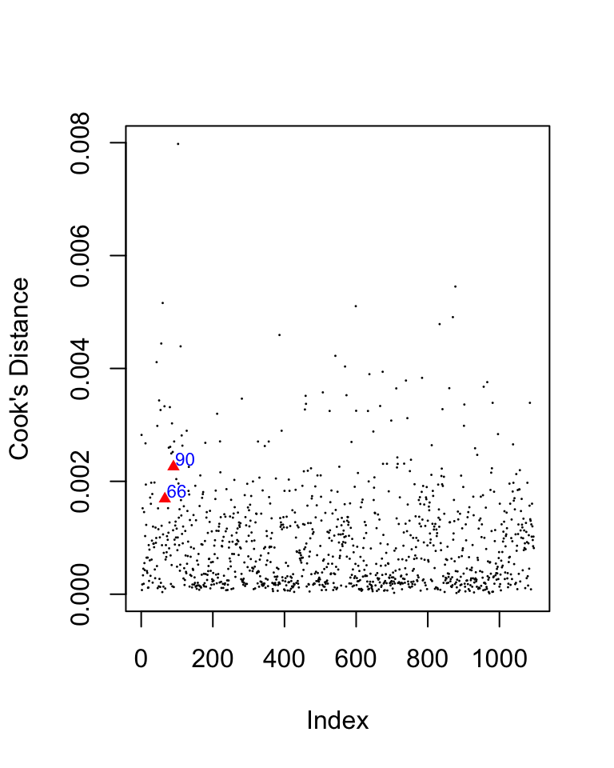

**Figure 10**

## 6. Linear Discriminant Analysis

We used Linear Discriminant Analysis (LDA) as an alternative classifier for predicting feedback type. In this approach, we estimate the distribution of each predictors given the response classes, and we used Bayes’ Theorem to calculated the probability of either classes given the values in predictors.

$$P(Y=1|X=\vec{x})=\frac{\pi_1f_1(\vec{x})}{\pi_1f_1(\vec{x})+\pi_2f_2(\vec{x})}$$

where $\pi_1$ is the prior distribution for randomly choose a observation from feedback class 1 (reward), $\pi_2$ is the prior distribution for randomly choose a observation from feedback class 2 (penalty), $f_1(\vec{x})$ is the conditional distribution of the predictor matrix $\bf{X}$ given the response is class 1, $f_2(\vec{x})$ is the conditional distribution of the predictor matrix $\bf{X}$ given the response is class 2.

LDA assumed each predictor follows a normal distribution and two classes in the response have identical covariance matrices.

We use `lda()` function in `MASS` package to fit LDA models. This time we fit `feedback_type` to all four predictors, the same predictors as the previous logistic regression model.

**Table 13**

|  | Prediction |  |
| --- | --- | --- |
|  | -1 | 1 |
| Observation |  |  |
| -1 | 6 | 20 |
| 1 | 2 | 72 |

Then we predicted the outcome using the same test set. It gives the same confusion matrix (see **Table 13**).

#### 6.1 ROC curves

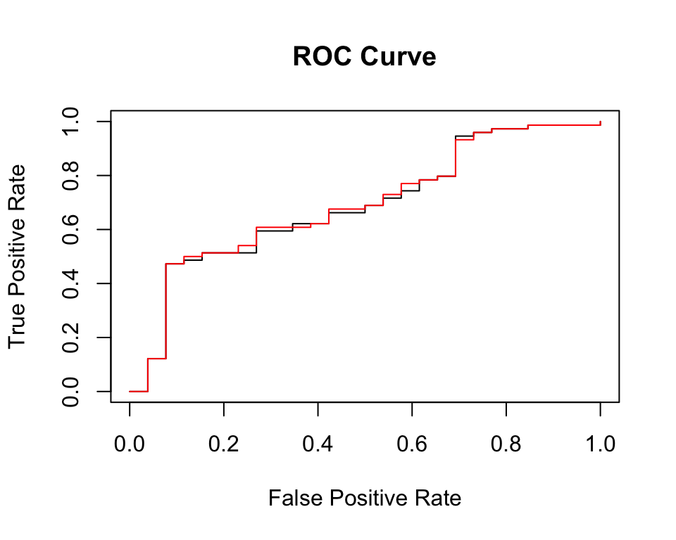

**Figure 11**

## 7. Conclusion

In addition, we fit a logistic regression model to predict the feedback type of whether a mouse receives a reward or penalty based on the reaction to the contrasts and mean firing rate. This model has an accuracy of 78% with a True Positive Rate of 97.3% and a False Positive Rate of 76.92%.

# Reference

Acknowledgement: Christopher Li, Lulu Xue, STA 207 Lecture notes and discussion notes.

Faraway, J. (2006). *Extending the Linear Model with R--Generalized Linear, Mixed Effects and Nonparametric Regression Models*. Chapman & Hall/CRC.

Meier, L. *ANOVA and Mixed Models–A Short Introduction Using R*. CRC Press.

James, G., Witten, D., Hastie, T., & Tibshirani, R. (2013). *An Introduction to Statistical Learning with Applications in R*. Springer.

Steinmetz, N.A., Zatka-Haas, P., Carandini, M. et al. Distributed coding of choice, action and engagement across the mouse brain. Nature 576, 266–273 (2019). https://doi.org/10.1038/s41586-019-1787-x

# Appendix

```r
# Data Import
pytsession=list()
session = list()
for(i in 1:5){
  session[[i]]=readRDS(paste('/Users/luyang/rstudio/STA 207/project/session',i,'.rds',sep=''))

}
library(dplyr)
library(ggplot2)
library(ROCR)
library(pander)
library(tidyverse)
library(gridExtra)
library(gplots)
library(DescTools)
library(car)
library(astsa)
library(MASS)


ID=1
t=0.4 # from Background

n.trials=length(session[[ID]]$spks)
n.neurons=dim(session[[ID]]$spks[[1]])[1]

firingrate1=numeric(n.trials)

for(i in 1:n.trials){
  firingrate1[i]=sum(session[[ID]]$spks[[i]])/n.neurons/t
}

ID=2
t=0.4 # from Background

n.trials=length(session[[ID]]$spks)
n.neurons=dim(session[[ID]]$spks[[1]])[1]

firingrate2=numeric(n.trials)

for(i in 1:n.trials){
  firingrate2[i]=sum(session[[ID]]$spks[[i]])/n.neurons/t
}

ID=3
t=0.4 # from Background

n.trials=length(session[[ID]]$spks)
n.neurons=dim(session[[ID]]$spks[[1]])[1]

firingrate3=numeric(n.trials)

for(i in 1:n.trials){
  firingrate3[i]=sum(session[[ID]]$spks[[i]])/n.neurons/t
}

ID=4
t=0.4 # from Background

n.trials=length(session[[ID]]$spks)
n.neurons=dim(session[[ID]]$spks[[1]])[1]

firingrate4=numeric(n.trials)

for(i in 1:n.trials){
  firingrate4[i]=sum(session[[ID]]$spks[[i]])/n.neurons/t
}

ID=5
t=0.4 # from Background

n.trials=length(session[[ID]]$spks)
n.neurons=dim(session[[ID]]$spks[[1]])[1]

firingrate5=numeric(n.trials)

for(i in 1:n.trials){
  firingrate5[i]=sum(session[[ID]]$spks[[i]])/n.neurons/t
}

ssn1 <- data.frame(contrast_left = session[[1]]$contrast_left,
                   contrast_right = session[[1]]$contrast_right,
                   firing_rate = firingrate1,
                   feedback_type = session[[1]]$feedback_type,
                   session = 1)

ssn2 <- data.frame(contrast_left = session[[2]]$contrast_left,
                   contrast_right = session[[2]]$contrast_right,
                   firing_rate = firingrate2,
                   feedback_type = session[[2]]$feedback_type,
                   session = 2)

ssn3 <- data.frame(contrast_left = session[[3]]$contrast_left,
                   contrast_right = session[[3]]$contrast_right,
                   firing_rate = firingrate3,
                   feedback_type = session[[3]]$feedback_type,
                   session = 3)

ssn4 <- data.frame(contrast_left = session[[4]]$contrast_left,
                   contrast_right = session[[4]]$contrast_right,
                   firing_rate = firingrate4,
                   feedback_type = session[[4]]$feedback_type,
                   session = 4)

ssn5 <- data.frame(contrast_left = session[[5]]$contrast_left,
                   contrast_right = session[[5]]$contrast_right,
                   firing_rate = firingrate5,
                   feedback_type = session[[5]]$feedback_type,
                   session = 5)

df <- rbind(ssn1, ssn2, ssn3, ssn4, ssn5)
df$session <- as.factor(df$session)
df$feedback_type <- as.factor(df$feedback_type)
df$contrast_left <- as.factor(df$contrast_left)
df$contrast_right <- as.factor(df$contrast_right)
```

```r
head(df) %>% pander(caption = '**Table 1**')

library(sqldf)
library(RSQLite)
sqldf('SELECT SESSION, COUNT(SESSION) AS "Number of Trials" FROM df GROUP BY SESSION') %>% pander(title = "**Table 2**")

library(ggplot2)
grid.arrange(ggplot(df) + geom_density(aes(x = firing_rate, fill = session), alpha = 0.6) + xlab('firing rate') + theme_bw() +xlab('Mean Firing Rate') + ylab('Density'),
             ggplot(df) + geom_density(aes(x = firing_rate, fill = feedback_type), alpha = 0.5)+ xlab('Mean Firing Rate') +ylab('Density') + theme_bw(),
             ncol = 2)

query1 <- sqldf('SELECT contrast_left, contrast_right, firing_rate
      FROM df GROUP BY contrast_left, contrast_right
      ORDER BY firing_rate DESC
      LIMIT 5')

query2 <- sqldf('SELECT contrast_left, contrast_right, firing_rate
      FROM df GROUP BY contrast_left, contrast_right
      ORDER BY firing_rate ASC
      LIMIT 5')

#pander(multicolumn = 2, multirow = 2, list(query1, query2), width = 'fit')

pander(query1, caption = "**Table 3(a)**")
pander(query2, caption = "**Table 3(b)**")


ggplot(df) + geom_boxplot(aes(x = firing_rate, y = session, fill= session)) + theme_bw() + xlab('Firing Rate')

df %>% group_by(contrast_right) %>% count() %>% pander(caption = "**Table 4(a)**")
df %>% group_by(contrast_left) %>% count() %>% pander(caption = "**Table 4(b)**")


library(lme4)
library(lmerTest)

model_full <- lmerTest::lmer(firing_rate ~ contrast_right*contrast_left + (1|session), data = df)

model_fixed_full <- lm(firing_rate ~ contrast_right*contrast_left, data = df)

model_add <- lmerTest::lmer(firing_rate ~ contrast_right + contrast_left + (1|session), data = df)

model_fixed <- lm(firing_rate ~ contrast_right+contrast_left, data = df)

coefs <- summary(model_full)$coef[,1]
coef_mat <- matrix(coefs, ncol = 4, byrow = T)
rownames(coef_mat) <- c('left 0', 'left 0.25', 'left 0.5', 'left 1')
colnames(coef_mat) <- c('right 0', 'right 0.25', 'right 0.5', 'right 1')


anova(model_full, model_add) %>% pander(caption = "**Table 6**")
anova(model_full, model_fixed_full) %>% pander(caption = "**Table 7**")

par(mfrow = c(2,2))
#plot(model_add, which = 1)
plot(summary(model_full)$residual, ylab = 'residual', type = 'p', cex = 0.5);abline(h=0, col = 'red')
qqnorm(summary(model_full)$residual);qqline(summary(model_add)$residual)
hist(summary(model_full)$residual, xlab = 'residual', main = 'Histogram of residuals')

shapiro.test(resid(model_full)) %>% pander(caption = "**Table 8**")
leveneTest(firing_rate~contrast_right*contrast_left, data = df) %>% pander(caption = "**Table 9(a)**")
leveneTest(resid(model_full)~contrast_right*contrast_left, data = df)%>% pander(caption = "**Table 9(b)**")
boxplot(resid(model_full), horizontal = T)

df_train <- df[101:nrow(df), ]
df_test <- df[1:100, ]

library(MASS)
logit_model <- glm(feedback_type ~ ., family = binomial(), data=df_train)

summary(logit_model)$coef %>% pander(digits = 4, caption = "**Table 10**")

h0_logit_model <- glm(feedback_type ~ .-session, family = binomial(), data = df_train)
anova(h0_logit_model, logit_model, test = 'Chi') %>%pander(caption = "**Table 11**")

logit_pred <- ifelse(predict(logit_model, df_test, type = "response") <.5, "-1", "1")

logit_cm=table(Feedback=df_test$feedback_type,Prediction=logit_pred)
logit_cm
sum(diag(logit_cm))/sum(logit_cm)

logit_cm[2,2]/(logit_cm[2,2]+logit_cm[2,1]) # TPR
logit_cm[1,2]/(logit_cm[1,2]+logit_cm[1,1]) # FPR

res.P = residuals(logit_model, type = "pearson")
res.D = residuals(logit_model, type = "deviance")
boxplot(cbind(res.P, res.D), names = c("Pearson", "Deviance"))

par(mfrow=c(1,2))
plot(logit_model$fitted.values, res.P, pch=16, cex=0.6, ylab='Pearson Residuals', xlab='Fitted Values')
lines(smooth.spline(logit_model$fitted.values, res.P, spar=0.9), col=2)
abline(h=0, lty=2, col='grey')
plot(logit_model$fitted.values, res.D, pch=16, cex=0.6, ylab='Deviance Residuals', xlab='Fitted Values')
lines(smooth.spline(logit_model$fitted.values, res.D, spar=0.9), col=2)
abline(h=0, lty=2, col='grey')

leverage = hatvalues(logit_model)
plot(names(leverage), leverage, xlab="Index", type="h")
points(names(leverage), leverage, pch=16, cex=0.5)
p = length(coef(logit_model))
n = nrow(df_train)
infPts = which(leverage>2*p/n)
abline(h=2*p/n,col=2,lwd=2,lty=2)

cooks = cooks.distance(logit_model)
plot(cooks, ylab="Cook's Distance", pch=16, cex=0.2)
points(infPts, cooks[infPts], pch=17, cex=0.8, col='red') # influential points
susPts = as.numeric(names(sort(cooks[infPts], decreasing=TRUE))[1:3]) - 100
text(susPts, cooks[susPts], susPts, adj=c(-0.1,-0.1), cex=0.7, col='blue')

lda_fit <- lda(feedback_type~contrast_left + contrast_right + session + firing_rate, data = df_train)
lda_pred <- predict(lda_fit, dplyr::select(df_test, -feedback_type))


lda_cm=table(Feedback=df_test$feedback_type, Prediction=lda_pred$class)

sum(diag(lda_cm))/sum(lda_cm)
lda_cm

lda_cm[2,2]/(lda_cm[2,2]+lda_cm[2,1]) # TPR
lda_cm[1,2]/(lda_cm[1,2]+lda_cm[1,1]) # FPR

library(ROCR)

# Logistic
logit_probs <- predict(logit_model, df_test, type = "response")
prediction_logit <- prediction(predictions = logit_probs, labels = df_test$feedback_type)

perf_logit <- performance(prediction.obj = prediction_logit, 'tpr', 'fpr')

# LDA
prediction_lda <- prediction(predictions = lda_pred$posterior[, 2],
labels = df_test$feedback_type)

perf_lda <- performance(prediction.obj = prediction_lda, 'tpr', 'fpr')
perf_lda

plot(perf_lda, main = "ROC Curve", xlab = "False Positive Rate", ylab = "True Positive Rate")
plot(perf_logit, col = 'red', add = T)
```